# PCA

Ted

2018年7月23日

## General methods for principal component analysis

### prcomp() and princomp() functions

```r
prcomp(x, scale = FALSE)
princomp(x, cor = FALSE, scores = TRUE)
```

Arguments for prcomp(): x: a numeric matrix or data frame scale: a logical value indicating whether the variables should be scaled to have unit variance before the analysis takes place

Arguments for princomp(): x: a numeric matrix or data frame cor: a logical value. If TRUE, the data will be centered and scaled before the analysis scores: a logical value. If TRUE, the coordinates on each principal component are calculated

| prcomp() name | princomp() name | Description |
| --- | --- | --- |
| sdev | sdev | the standard deviations of the principal components |
| rotation | loadings | the matrix of variable loadings (columns are eigenvectors) |
| center | center | the variable means (means that were substracted) |
| scale | scale | the variable standard deviations (the scaling applied to each variable ) |
| x | scores | The coordinates of the individuals (observations) on the principal components. |

### PCA visualization

use the factoextra R package to create a ggplot2-based elegant visualization.

1. Load the data
2. Load factoextra for visualization
3. Compute PCA
4. Visualize eigenvalues (scree plot). Show the percentage of variances explained by each principal component.
5. Graph of individuals. Individuals with a similar profile are grouped together.
6. Graph of variables. Positive correlated variables point to the same side of the plot. Negative correlated variables point to opposite sides of the graph.
7. Biplot of individuals and variables

```r
install.packages("factoextra")
# OR
if(!require(devtools)) install.packages("devtools")
devtools::install_github("kassambara/factoextra")
# then
library(factoextra)
```

```r
library("factoextra")
data(decathlon2)
decathlon2.active <- decathlon2[1:23, 1:10]
head(decathlon2.active[, 1:6])
```

```
##           X100m Long.jump Shot.put High.jump X400m X110m.hurdle
## SEBRLE    11.04      7.58    14.83      2.07 49.81        14.69
## CLAY      10.76      7.40    14.26      1.86 49.37        14.05
## BERNARD   11.02      7.23    14.25      1.92 48.93        14.99
## YURKOV    11.34      7.09    15.19      2.10 50.42        15.31
## ZSIVOCZKY 11.13      7.30    13.48      2.01 48.62        14.17
## McMULLEN  10.83      7.31    13.76      2.13 49.91        14.38
```

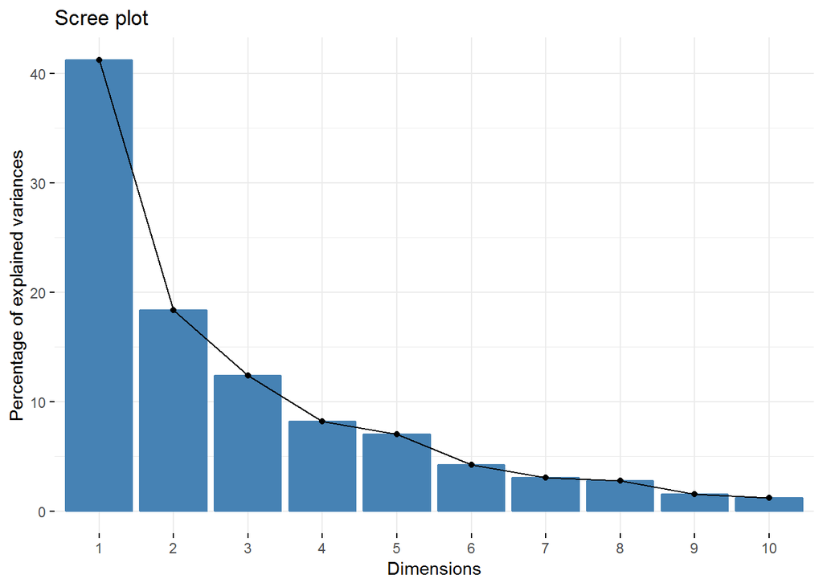

```r
res.pca <- prcomp(decathlon2.active, scale = TRUE)  # Compute PCA

fviz_eig(res.pca)  # Visualize eigenvalues
```

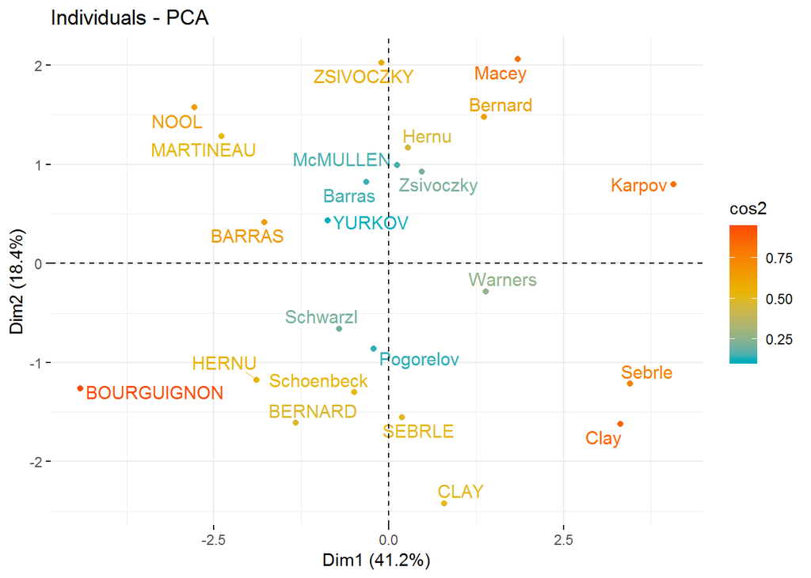

```r
fviz_pca_ind(res.pca,
             col.ind = "cos2", # Color by the quality of representation
             gradient.cols = c("#00AFBB", "#E7B800", "#FC4E07"),
             repel = TRUE     # Avoid text overlapping
             )  # Graph of individuals
```

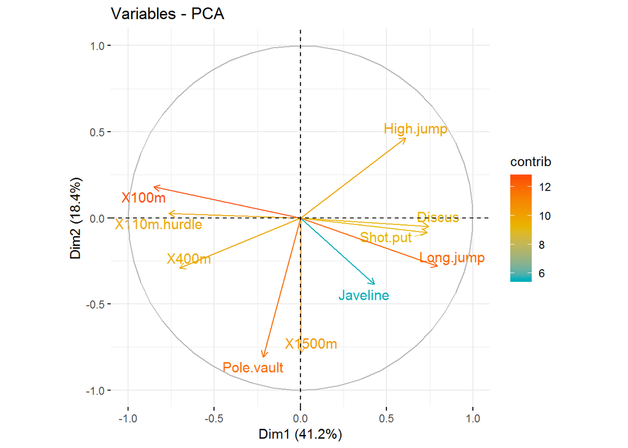

```r
fviz_pca_var(res.pca,
             col.var = "contrib", # Color by contributions to the PC
             gradient.cols = c("#00AFBB", "#E7B800", "#FC4E07"),
             repel = TRUE     # Avoid text overlapping
             )  # Graph of variables
```

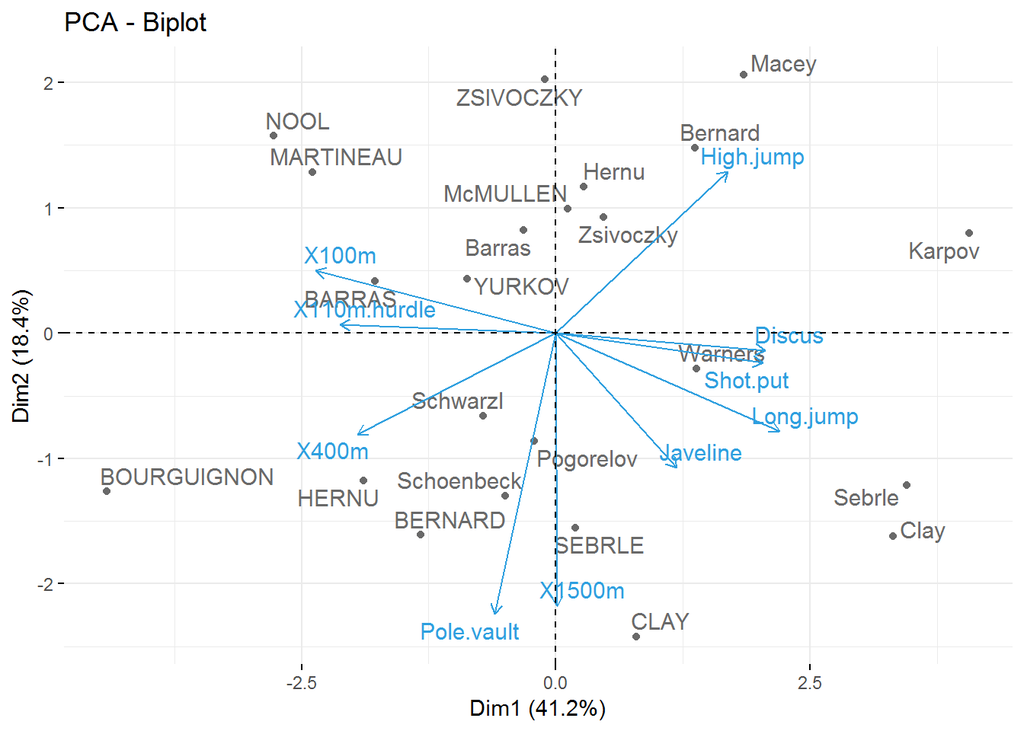

```r
fviz_pca_biplot(res.pca, repel = TRUE,
                col.var = "#2E9FDF", # Variables color
                col.ind = "#696969"  # Individuals color
                )  # Biplot of individuals and variables
```

### Access to the PCA results

```r
library(factoextra)

# Eigenvalues
eig.val <- get_eigenvalue(res.pca)
head(eig.val)
```

```
##       eigenvalue variance.percent cumulative.variance.percent
## Dim.1  4.1242133        41.242133                    41.24213
## Dim.2  1.8385309        18.385309                    59.62744
## Dim.3  1.2391403        12.391403                    72.01885
## Dim.4  0.8194402         8.194402                    80.21325
## Dim.5  0.7015528         7.015528                    87.22878
## Dim.6  0.4228828         4.228828                    91.45760
```

```r
# Results for Variables
res.var <- get_pca_var(res.pca)
head(res.var$coord)          # Coordinates
```

```
##                   Dim.1       Dim.2      Dim.3       Dim.4      Dim.5
## X100m        -0.8506257  0.17939806 -0.3015564  0.03357320 -0.1944440
## Long.jump     0.7941806 -0.28085695  0.1905465 -0.11538956  0.2331567
## Shot.put      0.7339127 -0.08540412 -0.5175978  0.12846837 -0.2488129
## High.jump     0.6100840  0.46521415 -0.3300852  0.14455012  0.4027002
## X400m        -0.7016034 -0.29017826 -0.2835329  0.43082552  0.1039085
## X110m.hurdle -0.7641252  0.02474081 -0.4488873 -0.01689589  0.2242200
##                     Dim.6        Dim.7        Dim.8       Dim.9
## X100m         0.035374780 -0.091336386 -0.104716925 -0.30306448
## Long.jump    -0.033727883 -0.154330810 -0.397380703 -0.05158951
## Shot.put     -0.239789034 -0.009886612  0.024359049  0.04778655
## High.jump    -0.284644846  0.028157465  0.084405578 -0.11213822
## X400m        -0.049289996  0.286106008 -0.233552216  0.08216041
## X110m.hurdle  0.002632395 -0.370072158 -0.008344682  0.16176025
##                   Dim.10
## X100m         0.04441797
## Long.jump     0.02971945
## Shot.put      0.21745195
## High.jump    -0.13356677
## X400m        -0.03417067
## X110m.hurdle -0.01562991
```

```r
head(res.var$contrib)        # Contributions to the PCs
```

```
##                  Dim.1      Dim.2     Dim.3       Dim.4     Dim.5
## X100m        17.544293  1.7505098  7.338659  0.13755240  5.389252
## Long.jump    15.293168  4.2904162  2.930094  1.62485936  7.748815
## Shot.put     13.060137  0.3967224 21.620432  2.01407269  8.824401
## High.jump     9.024811 11.7715838  8.792888  2.54987951 23.115504
## X400m        11.935544  4.5799296  6.487636 22.65090599  1.539012
## X110m.hurdle 14.157544  0.0332933 16.261261  0.03483735  7.166193
##                     Dim.6       Dim.7       Dim.8     Dim.9     Dim.10
## X100m         0.295915322  2.75705260  3.99520353 59.174001  1.6175614
## Long.jump     0.269003613  7.87159392 57.53322220  1.714683  0.7241439
## Shot.put     13.596858744  0.03230371  0.21618512  1.471201 38.7676858
## High.jump    19.159607001  0.26202607  2.59565787  8.101552 14.6264909
## X400m         0.574509906 27.05274658 19.87344405  4.348967  0.9573050
## X110m.hurdle  0.001638634 45.26163460  0.02537025 16.857939  0.2002887
```

```r
head(res.var$cos2)           # Quality of representation
```

```
##                  Dim.1        Dim.2      Dim.3        Dim.4      Dim.5
## X100m        0.7235641 0.0321836641 0.09093628 0.0011271597 0.03780845
## Long.jump    0.6307229 0.0788806285 0.03630798 0.0133147506 0.05436203
## Shot.put     0.5386279 0.0072938636 0.26790749 0.0165041211 0.06190783
## High.jump    0.3722025 0.2164242070 0.10895622 0.0208947375 0.16216747
## X400m        0.4922473 0.0842034209 0.08039091 0.1856106269 0.01079698
## X110m.hurdle 0.5838873 0.0006121077 0.20149984 0.0002854712 0.05027463
##                     Dim.6        Dim.7        Dim.8       Dim.9
## X100m        1.251375e-03 0.0083423353 1.096563e-02 0.091848077
## Long.jump    1.137570e-03 0.0238179990 1.579114e-01 0.002661478
## Shot.put     5.749878e-02 0.0000977451 5.933633e-04 0.002283554
## High.jump    8.102269e-02 0.0007928428 7.124302e-03 0.012574981
## X400m        2.429504e-03 0.0818566479 5.454664e-02 0.006750333
## X110m.hurdle 6.929502e-06 0.1369534023 6.963371e-05 0.026166378
##                    Dim.10
## X100m        0.0019729565
## Long.jump    0.0008832459
## Shot.put     0.0472853495
## High.jump    0.0178400831
## X400m        0.0011676349
## X110m.hurdle 0.0002442942
```

```r
# Results for individuals
res.ind <- get_pca_ind(res.pca)
head(res.ind$coord)          # Coordinates
```

```
##                Dim.1      Dim.2      Dim.3       Dim.4       Dim.5
## SEBRLE     0.1912074 -1.5541282 -0.6283688  0.08205241  1.14261394
## CLAY       0.7901217 -2.4204156  1.3568870  1.26984296 -0.80684837
## BERNARD   -1.3292592 -1.6118687 -0.1961500 -1.92092203  0.08234282
## YURKOV    -0.8694134  0.4328779 -2.4739822  0.69723814  0.39885841
## ZSIVOCZKY -0.1057450  2.0233632  1.3049312 -0.09929630 -0.19702411
## McMULLEN   0.1185550  0.9916237  0.8435582  1.31215266  1.58587086
##                Dim.6       Dim.7       Dim.8       Dim.9      Dim.10
## SEBRLE    -0.4638976 -0.20796012  0.04346057 -0.65934414  0.03273238
## CLAY       1.3042002 -0.21291866  0.61724061 -0.06012536 -0.31716015
## BERNARD   -0.4006287 -0.40643754  0.70385604  0.17008331 -0.09908142
## YURKOV     0.1028634 -0.32487448  0.11499613 -0.10952404 -0.11969720
## ZSIVOCZKY  0.8955411  0.08825624 -0.20234130 -0.52310310 -0.34842265
## McMULLEN   0.1865728  0.47828432  0.29308997 -0.10562320 -0.39317797
```

```r
head(res.ind$contrib)        # Contributions to the PCs
```

```
##                Dim.1      Dim.2      Dim.3       Dim.4      Dim.5
## SEBRLE    0.03854254  5.7118249  1.3854184  0.03572215  8.0911606
## CLAY      0.65814114 13.8541889  6.4600973  8.55568792  4.0345550
## BERNARD   1.86273218  6.1441319  0.1349983 19.57827284  0.0420207
## YURKOV    0.79686310  0.4431309 21.4755770  2.57939100  0.9859373
## ZSIVOCZKY 0.01178829  9.6816398  5.9748485  0.05231437  0.2405750
## McMULLEN  0.01481737  2.3253860  2.4967890  9.13531719 15.5864577
##                Dim.6     Dim.7      Dim.8      Dim.9     Dim.10
## SEBRLE     2.2125662 0.6214264 0.02992045 12.1774773 0.03819185
## CLAY      17.4880188 0.6514139 6.03512541  0.1012624 3.58568943
## BERNARD    1.6501984 2.3736528 7.84774707  0.8103198 0.34994507
## YURKOV     0.1087863 1.5165641 0.20948060  0.3360098 0.51072064
## ZSIVOCZKY  8.2456172 0.1119233 0.64855435  7.6649198 4.32741147
## McMULLEN   0.3578895 3.2870164 1.36075274  0.3125012 5.51053518
```

```r
head(res.ind$cos2)           # Quality of representation
```

```
##                 Dim.1      Dim.2       Dim.3       Dim.4        Dim.5
## SEBRLE    0.007530179 0.49747323 0.081325232 0.001386688 0.2689026575
## CLAY      0.048701249 0.45701660 0.143628117 0.125791741 0.0507850580
## BERNARD   0.197199804 0.28996555 0.004294015 0.411819183 0.0007567259
## YURKOV    0.096109800 0.02382571 0.778230322 0.061812637 0.0202279796
## ZSIVOCZKY 0.001574385 0.57641944 0.239754152 0.001388216 0.0054654972
## McMULLEN  0.002175437 0.15219499 0.110137872 0.266486530 0.3892621478
##                 Dim.6       Dim.7        Dim.8        Dim.9       Dim.10
## SEBRLE    0.044324130 0.008907507 0.0003890334 0.0895406730 0.0002206741
## CLAY      0.132690734 0.003536548 0.0297208402 0.0002820119 0.0078471026
## BERNARD   0.017913117 0.018436341 0.0552910432 0.0032285723 0.0010956493
## YURKOV    0.001345355 0.013419804 0.0016814404 0.0015252249 0.0018217256
## ZSIVOCZKY 0.112917691 0.001096685 0.0057644781 0.0385270286 0.0170924251
## McMULLEN  0.005387699 0.035406160 0.0132956152 0.0017267328 0.0239268142
```

### Theory behind PCA results

#### PCA results for variables

here we’ll show how to calculate the PCA results for variables: coordinates, cos2 and contributions:

1. `var.coord` = loadings * the component standard deviations
2. `var.cos2` = var.coord^2
3. `var.contrib` The contribution of a variable to a given principal component is (in percentage) : (var.cos2 * 100) / (total cos2 of the component)

#### PCA results for individuals

1. `ind.coord` = res.pca$x
2. Cos2 of individuals. Two steps:
- Calculate the square distance between each individual and the PCA center of gravity: d2 = [(var1_ind_i - mean_var1)/sd_var1]^2 + …+ [(var10_ind_i - mean_var10)/sd_var10]^2 + …+..
- Calculate the cos2 as ind.coord^2/d2
3. Contributions of individuals to the principal components: 100(1 / number_of_individuals)(ind.coord^2 / comp_sdev^2)

*Note that the sum of all the contributions per column is 100*